# Exos1 Linéaires

- Expl : **Action sur les données :**
- La différenciation réduit la taille de nos tableaux de 1. Par exemple, si nous avions 100 points de données, le tableau différencié n'en contiendra que 99, car la première différence est calculée entre le premier et le deuxième point. C'est une conséquence normale et attendue de l'opération.

```python
# 1. Créez un nouveau tableau numpy qui contient les premières valeurs différenciées du tableau long_waits
diff_long_waits = np.diff(long_waits)

# Affichons la taille des tableaux pour vérifier
print(f"Taille du tableau original long_waits : {len(long_waits)}")
print(f"Taille du tableau différencié diff_long_waits : {len(diff_long_waits)}")
```

```
Taille du tableau original long_waits : 80
Taille du tableau différencié diff_long_waits : 79
```

```python
diff_long_waits
```

```
array([ 7.96700000e+03,  6.26300000e+03, -9.77571430e+02,  4.34808571e+04,
       -1.70280000e+04, -2.59464286e+04,  1.22298572e+04, -1.79285715e+03,
       -2.57442857e+03, -3.10371428e+03, -6.81628572e+03,  1.91142860e+02,
        1.03158571e+04,  7.06028572e+03, -3.32085715e+03,  1.37001429e+04,
        9.14571430e+02,  1.16805714e+04, -1.84801429e+04, -2.38600000e+03,
       -3.04028571e+03, -8.14285800e+01, -5.00571428e+03, -1.82657143e+03,
        4.50314286e+03,  9.75828571e+03,  1.14585714e+03,  2.71722857e+04,
       -2.62514286e+03, -4.49142860e+02,  2.68827143e+04, -8.73285700e+02,
       -5.52984286e+04, -8.48328571e+03,  9.24871429e+03,  2.80742857e+03,
        6.14757143e+03,  4.70628571e+03, -8.46885714e+03,  1.32681428e+04,
       -5.35714200e+01,  5.10557142e+03, -3.27257142e+03,  3.12842857e+03,
        1.32325714e+04, -9.32600001e+03,  3.40828571e+03, -7.39228571e+03,
        1.09700000e+04,  1.91284286e+04,  7.53000000e+02,  7.24238571e+04,
       -3.89985714e+04, -2.02885715e+04,  8.32614290e+03, -1.53947143e+04,
       -1.55148571e+04, -1.09604286e+04, -1.84900000e+03,  9.00000000e+03,
        1.66360000e+04,  2.44430000e+04,  1.59180000e+04,  5.13200000e+03,
        4.76820000e+04,  1.27950000e+04,  3.67530000e+04, -7.97120000e+04,
        1.52070000e+04, -1.64170000e+04,  1.70610000e+04, -2.75540000e+04,
        8.17800000e+03,  3.65400000e+04,  2.57600000e+03,  4.71050000e+04,
        1.27940000e+04, -6.51960000e+04, -1.50240000e+04])
```

```python
# 2. Créez un nouveau tableau numpy qui contient les premières valeurs différenciées du tableau DTOCS
diff_dtocs = np.diff(dtocs)
```

3. - Tracez les données sous forme de nuage de points

Maintenant que nous avons les changements mensuels pour chaque variable, nous pouvons les visualiser pour voir s'il existe une relation apparente entre eux. Nous allons mettre en graphique le changement de DTOCS (variable indépendante, axe X) par rapport au changement de long_waits (variable dépendante, axe Y).

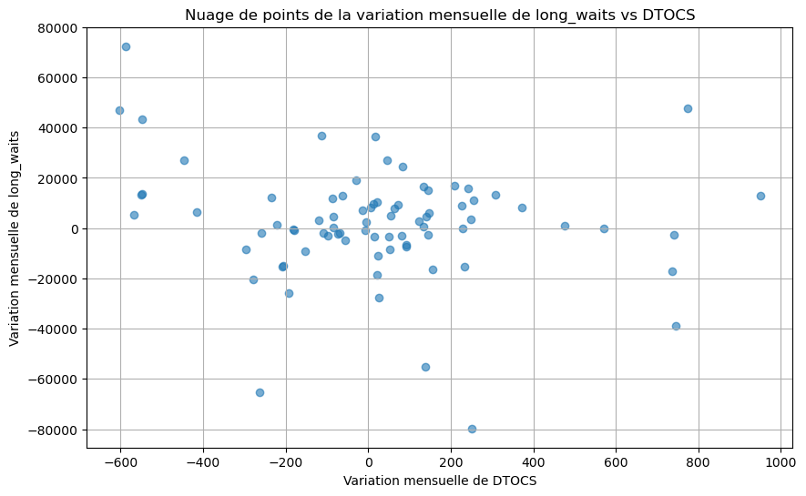

```python
# 3. Tracez les données sous forme de nuage de points
plt.figure(figsize=(10, 6))
plt.scatter(diff_dtocs, diff_long_waits, alpha=0.6) # alpha pour la transparence des points

# Ajout des titres et des labels pour la clarté
plt.title('Nuage de points de la variation mensuelle de long_waits vs DTOCS')
plt.xlabel('Variation mensuelle de DTOCS')
plt.ylabel('Variation mensuelle de long_waits')
plt.grid(True) # Ajoute une grille pour une meilleure lisibilité
plt.show()
```

4. - Effectuer une régression linéaire à l'aide de modèles de statistiques sur ces données différenciées
- Réponse : Effectuer une régression linéaire Visuellement, il peut y avoir une tendance. Pour la quantifier, nous effectuons une régression linéaire. Ce modèle va tenter de trouver la ligne droite qui passe au mieux à travers notre nuage de points.

Note importante : La librairie statsmodels requiert que l'on ajoute manuellement une constante (l'intercept ou ordonnée à l'origine) à notre variable indépendante. C'est ce que fait la ligne sm.add_constant().

```python
# 4. Effectuer une régression linéaire à l'aide de modèles de statistiques sur ces données différenciées

# Définition de la variable indépendante (X) et de la variable dépendante (Y)
X = diff_dtocs
Y = diff_long_waits

# Ajout de la constante (intercept) à notre variable indépendante
X_with_const = sm.add_constant(X)

# Création et entraînement (fit) du modèle de régression linéaire (Ordinary Least Squares)
model = sm.OLS(Y, X_with_const)
results = model.fit()

# Affichage du résumé complet des résultats de la régression
print(results.summary())
```

```
                            OLS Regression Results
==============================================================================
Dep. Variable:                      y   R-squared:                       0.035
Model:                            OLS   Adj. R-squared:                  0.022
Method:                 Least Squares   F-statistic:                     2.775
Date:                Sat, 25 Oct 2025   Prob (F-statistic):             0.0998
Time:                        03:39:33   Log-Likelihood:                -901.09
No. Observations:                  79   AIC:                             1806.
Df Residuals:                      77   BIC:                             1811.
Df Model:                           1
Covariance Type:            nonrobust
==============================================================================
                 coef    std err          t      P>|t|      [0.025      0.975]
------------------------------------------------------------------------------
const       2417.0761   2484.505      0.973      0.334   -2530.206    7364.358
x1           -13.3144      7.992     -1.666      0.100     -29.229       2.600
==============================================================================
Omnibus:                       16.746   Durbin-Watson:                   2.174
Prob(Omnibus):                  0.000   Jarque-Bera (JB):               39.038
Skew:                          -0.640   Prob(JB):                     3.33e-09
Kurtosis:                       6.197   Cond. No.                         312.
==============================================================================

Notes:
[1] Standard Errors assume that the covariance matrix of the errors is correctly specified.
```

5. - ajoutez votre ligne de régression au nuage de points

Pour visualiser le résultat de notre modèle, nous allons tracer la ligne de régression calculée sur le nuage de points existant. Cette ligne représente la prédiction du modèle pour la variation de long_waits en fonction de la variation de DTOCS.

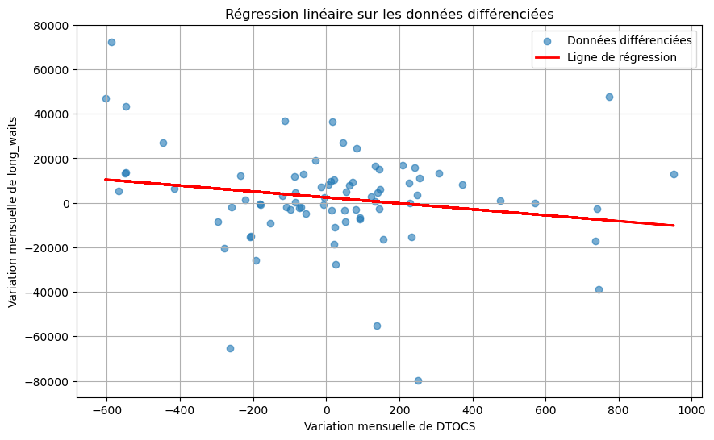

```python
# 5. Ajoutez votre ligne de régression au nuage de points

# Récupération de l'intercept (const) et de la pente (coefficient de X)
intercept, slope = results.params

# Création de la figure et du nuage de points (comme à l'étape 3)
plt.figure(figsize=(10, 6))
plt.scatter(X, Y, alpha=0.6, label='Données différenciées')

# Ajout de la ligne de régression
# On la dessine en utilisant la formule y = slope * x + intercept
plt.plot(X, slope * X + intercept, color='red', linewidth=2, label='Ligne de régression')

# Ajout des titres, labels et légende
plt.title('Régression linéaire sur les données différenciées')
plt.xlabel('Variation mensuelle de DTOCS')
plt.ylabel('Variation mensuelle de long_waits')
plt.legend()
plt.grid(True)
plt.show()
```

6. - décrire ce qu'indiquent les valeurs p, les intervalles de confiance et les valeurs r au carré.

[figure not shown]

Le tableau de résumé généré par statsmodels est riche en informations. Concentrons-nous sur les trois indicateurs clés que vous avez mentionnés.

## Les P-valeurs (colonne P>|t|)

Qu'est-ce que c'est ? La p-valeur teste l'hypothèse nulle, qui stipule qu'un coefficient n'a aucun effet sur la variable dépendante (en d'autres termes, que sa vraie valeur est zéro).

**Le lien avec la Loi Normale :**

- Pour calculer cette probabilité, on calcule un t-statistic. Ce score mesure à combien d'écarts-types notre coefficient estimé se trouve de zéro.
- On compare ensuite ce score à une distribution t de Student, qui est une cousine très proche de la loi normale (elle lui ressemble et converge vers elle avec suffisamment de données).
- La p-valeur est l'aire sous les deux queues de cette courbe en cloche, au-delà de notre t-statistic. Une petite aire (p-valeur < 0.05) signifie que notre résultat est très loin de zéro, dans une zone "improbable" de la distribution. Il est donc peu probable que ce soit dû au hasard.

**Comment l'interpréter ?**

- Une petite p-valeur (typiquement < 0.05) suggère que l'on peut rejeter l'hypothèse nulle.
- Cela signifie que le coefficient est statistiquement significatif et qu'il y a une réelle relation entre la variation de DTOCS et la variation de long_waits.
- Une p-valeur élevée (> 0.05) suggère que le coefficient n'est pas significatif et que l'effet observé pourrait être dû au hasard.

**Dans notre contexte :**

- Regardez la p-valeur associée à la variable x1 (qui représente diff_dtocs). Si elle est faible, cela renforce l'idée qu'un changement dans DTOCS est associé de manière fiable à un changement dans long_waits.

## Les Intervalles de Confiance (colonnes [0.025 et 0.975])

**Le lien avec la Loi Normale :**

- La construction de cet intervalle est directement basée sur la forme de la courbe en cloche. Pour un intervalle de confiance à 95%, on prend la valeur de notre coefficient et on construit une plage autour de lui qui correspond **à 95% de l'aire centrale de la distribution.**

**Qu'est-ce que c'est ?**

- L'intervalle de confiance à 95% nous donne une plage de valeurs dans laquelle nous sommes sûrs à 95% que se trouve le vrai coefficient de la population. Le coefficient calculé à partir de notre échantillon n'est qu'une estimation.

**Comment l'interpréter ?**

- Un intervalle étroit indique une estimation précise. Un intervalle large indique beaucoup d'incertitude.
- Si l'intervalle de confiance contient la valeur 0, cela corrobore une p-valeur élevée : il est plausible que le vrai coefficient soit zéro, et donc qu'il n'y ait pas d'effet réel.

**Dans notre contexte :** L'intervalle pour x1 nous donne la plage plausible pour l'impact réel d'une unité de changement de DTOCS sur long_waits.

**En résumé : La loi normale** nous fournit le "mètre étalon" pour définir la largeur de l'intervalle autour de notre estimation, nous permettant de quantifier notre incertitude. Si cet intervalle est large, notre estimation est peu précise. S'il ne contient pas zéro, c'est une autre façon de dire que notre coefficient est statistiquement significatif.

## La valeur R-carré (R-squared)

Qu'est-ce que c'est ? Le R² mesure la proportion de la variance de la variable dépendante qui est expliquée par notre modèle.

**Le lien (indirect) avec la Loi Normale :** Le calcul du R² lui-même ne dépend pas de la loi normale. C'est une mesure descriptive. Cependant, pour savoir si notre R² est statistiquement significatif (c'est-à-dire si notre modèle explique une part de la variance qui n'est pas due au hasard), on utilise un F-test. Ce test compare la variance expliquée par le modèle à la variance résiduelle (les erreurs). Et, comme pour les autres tests, la distribution F utilisée pour ce test est dérivée en supposant que les résidus sont normalement distribués.

### La valeur R-carré (R-squared)

Qu'est-ce que c'est ? Le R² mesure la proportion de la variance de la variable dépendante (la variation de long_waits) qui est expliquée par la variable indépendante (la variation de DTOCS). Sa valeur est toujours comprise entre 0 et 1.

**Comment l'interpréter ?** Un R² de 0 signifie que le modèle n'explique rien de la variabilité de la réponse. Un R² de 1 signifie qu'il explique toute la variabilité. Un R² de 0.45 signifie que 45% de la variance des changements de long_waits peut être expliquée par les changements de DTOCS.

**Attention :** Un R² élevé ne signifie pas forcément que le modèle est bon, et un R² faible ne signifie pas qu'il est mauvais. Le contexte est roi ! Dans des systèmes complexes avec de nombreuses variables, un R² faible peut quand même être très significatif. Pour une analyse plus robuste, on se réfère souvent à l'Adj. R-squared (R-carré ajusté), qui pénalise l'ajout de variables inutiles au modèle.

# Plots résiduelles

Ici, nous allons maintenant nous concentrer sur la façon de produire certains des tracés de diagnostic en python qui nous aident à évaluer ces problèmes. D'après mon expérience, produire ces tracés en python demande parfois beaucoup plus de réflexion/de travail que d'utiliser des packages R spécialisés pour ce type de travail statistique.

### Normalité

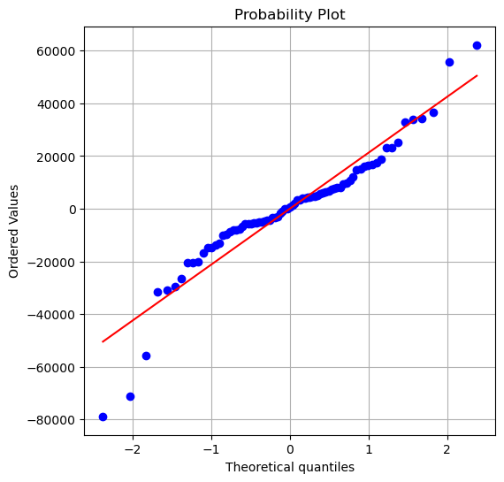

```python
from scipy.stats import probplot
fig, ax = plt.subplots(figsize=(6,6))
probplot(results.resid, plot=ax, fit=True) # the .resid attribute contains a numpy array of the residuals
plt.grid(True)
```

## Linéarité et variance non constante

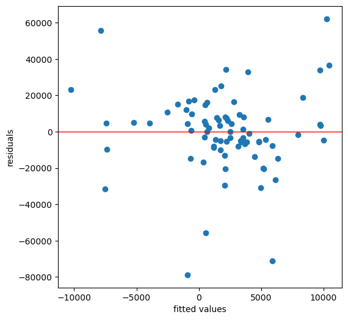

```python
fig, ax = plt.subplots(figsize=(6,6))
plt.scatter(results.fittedvalues, results.resid)
ax.set_xlabel('fitted values')
ax.set_ylabel('residuals')
ax.axhline(linewidth=1, color='r')
plt.show()
```

**Tâche 3** :

- Reproduisez les graphiques ci-dessus mais pour le modèle qui utilisait les données différenciées que vous avez produites précédemment.
- Que concluriez-vous de chacune de ces intrigues ? Votre modèle ajusté satisfait-il à toutes les hypothèses garantissant qu’il est fiable ?

```python
#### your answer here
```

## Sélection de variables

Habituellement, nous pouvons avoir plusieurs mesures et nous ne savons pas lesquelles sont capables d'expliquer le mieux la variable que nous essayons de prédire. Ensuite, nous utilisons la régression linéaire *multiple* pour déterminer quelles variables sont importantes.

Par exemple, nous pouvons considérer l’effet des budgets publicitaires de divers médias sur les ventes globales d’un produit. Voir **ISLR** chapitre 3. Ici, la télévision, la radio et les journaux sont des budgets publicitaires individuels et les ventes correspondent au nombre total d'un produit vendu.

```python
#### import advertising data
advertising = pd.read_csv('./data/Advertising.csv', usecols=[1,2,3,4])
advertising.head()
```

|  | TV | Radio | Newspaper | Sales |
| --- | --- | --- | --- | --- |
| 0 | 230.1 | 37.8 | 69.2 | 22.1 |
| 1 | 44.5 | 39.3 | 45.1 | 10.4 |
| 2 | 17.2 | 45.9 | 69.3 | 9.3 |
| 3 | 151.5 | 41.3 | 58.5 | 18.5 |
| 4 | 180.8 | 10.8 | 58.4 | 12.9 |

Nous pouvons utiliser des modèles de statistiques pour ajuster un modèle de régression linéaire *multiple* en utilisant le même code que précédemment. Il faudra un tableau 1D comme variable $Y$ et une matrice numpy 2D pour les variables $X$ (où chaque colonne représente les données associées à $X1, X2, ...X_{p}$).

**Remarque : nous transmettons maintenant une série pandas (pour $Y$, 1d) et une dataframe pandas (pour $X$, 2d). C'est beaucoup plus pratique car statsmodels sait utiliser les titres des séries/dataframes comme étiquettes pour notre sortie récapitulative.**

```python
def perform_linear_regression(Y,X):
    """
    Function performs linear regression, prints adjusted r-squared and coef table, and returns the model results object.

    Input
    =====
    Y, pandas series,
    X, pandas dataframe,

    Return
    ======
    results, statsmodel linear regression results object

    """
    # fit multiple linear regression model
    X = sm.add_constant(X) # an intercept term to the model
    model = sm.OLS(Y, X)
    results = model.fit()
    # print results
    print('Adjusted R-squared: {0:1.3f}'.format(results.rsquared_adj))
    print(results.summary().tables[1])
    return(results)


sales = advertising['Sales']
media_budgets = advertising[['TV','Radio','Newspaper']]

results = perform_linear_regression(sales, media_budgets)
```

```
Adjusted R-squared: 0.896
==============================================================================
                 coef    std err          t      P>|t|      [0.025      0.975]
------------------------------------------------------------------------------
const          2.9389      0.312      9.422      0.000       2.324       3.554
TV             0.0458      0.001     32.809      0.000       0.043       0.049
Radio          0.1885      0.009     21.893      0.000       0.172       0.206
Newspaper     -0.0010      0.006     -0.177      0.860      -0.013       0.011
==============================================================================
```

En sélectionnant un bon modèle qui utilise uniquement des variables importantes du budget média pour expliquer la relation entre les ventes, nous supprimerions probablement la variable Journal de notre modèle (voir le chapitre 3 pour une explication détaillée de cela). Comme vous pouvez le voir ci-dessous, la valeur r-carré ajustée est similaire et nous n'avons donc perdu aucune information dans notre modèle. C'était une bonne décision.

```python
sales = advertising['Sales']
media_budgets = advertising[['TV','Radio']]

results = perform_linear_regression(sales, media_budgets)
```

```
Adjusted R-squared: 0.896
==============================================================================
                 coef    std err          t      P>|t|      [0.025      0.975]
------------------------------------------------------------------------------
const          2.9211      0.294      9.919      0.000       2.340       3.502
TV             0.0458      0.001     32.909      0.000       0.043       0.048
Radio          0.1880      0.008     23.382      0.000       0.172       0.204
==============================================================================
```

### Exercice 3 : Détermination de la teneur en alcool d'un vin à l'aide d'autres caractéristiques

Vous trouverez un ensemble de données contenant les attributs de différents types de vins dans `wine.csv` dans le dossier data. Votre tâche consiste à déterminer quelles autres variables sont importantes pour expliquer la teneur en alcool.

Vous devez :

1. - effectuer une régression linéaire en utilisant toutes les variables
2. - écrire un morceau de code pour implémenter la sélection arrière.

Votre solution, à chaque étape de la sélection, doit : 3. * imprimer le nom de la variable supprimée 4. * imprimer le r-carré ajusté 5. * renvoie les résultats du coefficient et de la valeur p de chaque variable

Vous devez utiliser la sortie de votre code pour répondre : 6. * Combien de variables ont été supprimées pour ne finir avec que des variables significatives ? 7. * Quelles variables restent dans votre modèle ?

INDICE 8. * supposons que la règle d'arrêt est que vous vous arrêtez lorsqu'il n'y a que des variables significatives contenues dans votre modèle)

## Introduction : Le défi de la Sélection de Variables

En analyse de données, il est rare de travailler avec seulement une ou deux variables. Le plus souvent, nous disposons d'une multitude de "prédicteurs" (variables indépendantes) et nous cherchons à savoir lesquels sont réellement utiles pour expliquer une "cible" (variable dépendante).

**Lancer une régression avec toutes les variables disponibles peut être contre-productif :**

**Le "Bruit" :** Certaines variables n'ont aucun lien réel avec notre cible. Les inclure peut obscurcir les signaux importants et rendre le modèle moins performant.

**La Multicolinéarité :** Certaines variables prédictives peuvent être fortement corrélées entre elles, ce qui rend difficile l'interprétation des coefficients individuels.

- Pour résoudre ce problème, nous utilisons des techniques de sélection de variables.
- Aujourd'hui, nous allons implémenter l'une des plus intuitives : la sélection arrière (ou backward elimination).

L'idée est simple :

1. On commence avec un modèle incluant toutes les variables.
2. On identifie la "pire" variable, celle qui est la moins significative statistiquement.
3. On la retire du modèle.
4. On recommence l'opération jusqu'à ce qu'il ne reste que des variables significatives.

```python
#### import wine data
wine = pd.read_csv('./data/wine.csv', usecols=[1,2,3,4,5,6,7,8,9,10,11,12,13,])
wine.head()
```

|  | Alcohol | Malic acid | Ash | Alcalinity of ash | Magnesium | Total phenols | Flavanoids | Nonflavanoid phenols | Proanthocyanins | Color intensity | Hue | OD280/OD315 of diluted wines | Proline |
| --- | --- | --- | --- | --- | --- | --- | --- | --- | --- | --- | --- | --- | --- |
| 0 | 1.51 | -0.56 | 0.23 | -1.17 | 1.91 | 0.81 | 1.03 | -0.66 | 1.22 | 0.25 | 0.36 | 1.84 | 1.01 |
| 1 | 0.25 | -0.50 | -0.83 | -2.48 | 0.02 | 0.57 | 0.73 | -0.82 | -0.54 | -0.29 | 0.40 | 1.11 | 0.96 |
| 2 | 0.20 | 0.02 | 1.11 | -0.27 | 0.09 | 0.81 | 1.21 | -0.50 | 2.13 | 0.27 | 0.32 | 0.79 | 1.39 |
| 3 | 1.69 | -0.35 | 0.49 | -0.81 | 0.93 | 2.48 | 1.46 | -0.98 | 1.03 | 1.18 | -0.43 | 1.18 | 2.33 |
| 4 | 0.29 | 0.23 | 1.84 | 0.45 | 1.28 | 0.81 | 0.66 | 0.23 | 0.40 | -0.32 | 0.36 | 0.45 | -0.04 |

```python
wine.columns
```

```
Index(['Alcohol', 'Malic acid', 'Ash', 'Alcalinity of ash', 'Magnesium',
       'Total phenols', 'Flavanoids', 'Nonflavanoid phenols',
       'Proanthocyanins', 'Color intensity', 'Hue',
       'OD280/OD315 of diluted wines', 'Proline'],
      dtype='object')
```

1. - effectuer une régression linéaire en utilisant toutes les variables

```python
def perform_linear_regression(Y,X):
    """
    Function performs linear regression, prints adjusted r-squared and coef table, and returns the model results object.

    Input
    =====
    Y, pandas series,
    X, pandas dataframe,

    Return
    ======
    results, statsmodel linear regression results object

    """
    # fit multiple linear regression model
    X = sm.add_constant(X) # an intercept term to the model
    model = sm.OLS(Y, X)
    results = model.fit()
    # print results
    print('Adjusted R-squared: {0:1.3f}'.format(results.rsquared_adj))
    print(results.summary().tables[1])
    return(results)


alcool = wine['Alcohol']
modif_OH = wine[['Malic acid', 'Ash', 'Alcalinity of ash', 'Magnesium',
       'Total phenols', 'Flavanoids', 'Nonflavanoid phenols',
       'Proanthocyanins', 'Color intensity', 'Hue',
       'OD280/OD315 of diluted wines', 'Proline']]

results = perform_linear_regression(alcool, modif_OH)
```

```
Adjusted R-squared: 0.564
================================================================================================
                                   coef    std err          t      P>|t|      [0.025      0.975]
------------------------------------------------------------------------------------------------
const                           -0.0003      0.049     -0.006      0.995      -0.098       0.097
Malic acid                       0.1806      0.062      2.902      0.004       0.058       0.303
Ash                              0.0461      0.073      0.630      0.529      -0.098       0.191
Alcalinity of ash               -0.1544      0.073     -2.110      0.036      -0.299      -0.010
Magnesium                       -0.0003      0.059     -0.006      0.996      -0.117       0.116
Total phenols                    0.0414      0.103      0.402      0.688      -0.162       0.245
Flavanoids                       0.0106      0.132      0.080      0.936      -0.249       0.270
Nonflavanoid phenols            -0.0321      0.066     -0.483      0.630      -0.163       0.099
Proanthocyanins                 -0.1078      0.069     -1.558      0.121      -0.244       0.029
Color intensity                  0.4642      0.078      5.932      0.000       0.310       0.619
Hue                              0.0601      0.079      0.760      0.448      -0.096       0.216
OD280/OD315 of diluted wines     0.1398      0.096      1.459      0.146      -0.049       0.329
Proline                          0.3958      0.077      5.108      0.000       0.243       0.549
================================================================================================
```

```python
# le R-squared = 0.564 (au dessus) => 100% la variance est de 70%  pour que ça soit valider pas en dessous c a d 70% du R^2 soit 0.392
```

2. - écrire un morceau de code pour implémenter la sélection arrière.

On réduit le nombre de colonne utiliser coeff Graff y = R^2 peut être fait avec MSE/MAE/ F1/...(métrique) c'est la variance doit être prét de 70% c'est à dire le R^2 (ici); x est le nb feature (colonne)

On ne peut pas rejetter si le coeff est nul

On réduit le nb de feature (colonne) au fure et à mesure la complexité de la régression c'est la réduction de dimension (avec la PSA(technique))

3. On la retire du modèle. J'ai supprimer les colonnes : Magnésium car la p-valus > 0.996 sur le TBprécédent

```python
alcool = wine['Alcohol']
modif_OH = wine[['Malic acid', 'Ash', 'Alcalinity of ash',
       'Total phenols', 'Flavanoids', 'Nonflavanoid phenols',
       'Proanthocyanins', 'Color intensity', 'Hue',
       'OD280/OD315 of diluted wines', 'Proline']]

results = perform_linear_regression(alcool, modif_OH)
```

```
Adjusted R-squared: 0.567
================================================================================================
                                   coef    std err          t      P>|t|      [0.025      0.975]
------------------------------------------------------------------------------------------------
const                           -0.0003      0.049     -0.006      0.995      -0.098       0.097
Malic acid                       0.1806      0.062      2.912      0.004       0.058       0.303
Ash                              0.0460      0.070      0.657      0.512      -0.092       0.184
Alcalinity of ash               -0.1543      0.073     -2.120      0.036      -0.298      -0.011
Total phenols                    0.0414      0.103      0.403      0.687      -0.162       0.244
Flavanoids                       0.0107      0.130      0.082      0.935      -0.247       0.268
Nonflavanoid phenols            -0.0320      0.063     -0.504      0.615      -0.157       0.093
Proanthocyanins                 -0.1078      0.068     -1.593      0.113      -0.241       0.026
Color intensity                  0.4642      0.078      5.950      0.000       0.310       0.618
Hue                              0.0601      0.079      0.763      0.446      -0.095       0.216
OD280/OD315 of diluted wines     0.1399      0.095      1.476      0.142      -0.047       0.327
Proline                          0.3957      0.076      5.218      0.000       0.246       0.545
================================================================================================
```

4. 1. On recommence l'opération jusqu'à ce qu'il ne reste que des variables significatives.

**Boucle d'Élimination Rétrograde (Processus par Entonnoir)** Ce bloc de code exécute la méthode par entonnoir. Il retire les prédicteurs non pertinents (p-value >0.05) un par un, en choisissant toujours celui avec la p-value maximale parmi les non significatifs.

```python
# Scripte une boucle for pour effacer les colonne les moins pertinentes
wine_alc = wine['Alcohol']
wine_minus_alc = wine.drop(columns=['Alcohol'])

p_value = 0.05

print("récupére la derniére sélection : ")
for columns in wine_minus_alc:

    # Linear regression
    x = sm.add_constant(wine_minus_alc) # ajouter un terme d'interception au modèle
    model = sm.OLS(wine_alc, x)
    results = model.fit()

    print(f"Rsquared après sélection : {results.rsquared_adj}")

    max_pvalue = results.pvalues.drop('const').max()

    if(max_pvalue > p_value):
        key = results.pvalues.drop('const').idxmax()
        print(f"colonne enlever {key}\n    pvalue {dict(results.pvalues)[key]}\n    coef {dict(results.params)[key]}")
        wine_minus_alc = wine_minus_alc.drop(columns=[key])
    else:
        break

print(results.summary())
```

```
récupére la derniére sélection :
Rsquared après sélection : 0.5644976520685074
colonne enlever Magnesium
    pvalue 0.9955537403371555
    coef -0.00032958108160364985
Rsquared après sélection : 0.5671210784715595
colonne enlever Flavanoids
    pvalue 0.9349379550520815
    coef 0.010658343554924066
Rsquared après sélection : 0.5696958414990684
colonne enlever Nonflavanoid phenols
    pvalue 0.5915142950612888
    coef -0.03314417381563138
Rsquared après sélection : 0.5715166967069589
colonne enlever Total phenols
    pvalue 0.554584898864221
    coef 0.04986891643336809
Rsquared après sélection : 0.5731632564078493
colonne enlever Ash
    pvalue 0.47752602004480116
    coef 0.04693133241525353
Rsquared après sélection : 0.5744016837769221
colonne enlever Hue
    pvalue 0.3910502959689769
    coef 0.06517936437500065
Rsquared après sélection : 0.5750501778833985
colonne enlever Proanthocyanins
    pvalue 0.12647034440431854
    coef -0.09153254114999235
Rsquared après sélection : 0.5716944401928368
                            OLS Regression Results
==============================================================================
Dep. Variable:                Alcohol   R-squared:                       0.584
Model:                            OLS   Adj. R-squared:                  0.572
Method:                 Least Squares   F-statistic:                     48.25
Date:                Sat, 25 Oct 2025   Prob (F-statistic):           5.04e-31
Time:                        03:39:33   Log-Likelihood:                -173.99
No. Observations:                 178   AIC:                             360.0
Df Residuals:                     172   BIC:                             379.1
Df Model:                           5
Covariance Type:            nonrobust
================================================================================================
                                   coef    std err          t      P>|t|      [0.025      0.975]
------------------------------------------------------------------------------------------------
const                           -0.0002      0.049     -0.005      0.996      -0.097       0.097
Malic acid                       0.1615      0.055      2.946      0.004       0.053       0.270
Alcalinity of ash               -0.1333      0.057     -2.352      0.020      -0.245      -0.021
Color intensity                  0.4334      0.065      6.647      0.000       0.305       0.562
OD280/OD315 of diluted wines     0.1450      0.065      2.234      0.027       0.017       0.273
Proline                          0.4343      0.066      6.555      0.000       0.304       0.565
==============================================================================
Omnibus:                        0.858   Durbin-Watson:                   1.939
Prob(Omnibus):                  0.651   Jarque-Bera (JB):                0.520
Skew:                           0.069   Prob(JB):                        0.771
Kurtosis:                       3.226   Cond. No.                         2.67
==============================================================================

Notes:
[1] Standard Errors assume that the covariance matrix of the errors is correctly specified.
```

```python
final_r_squared_adj = results.rsquared_adj
seuil_r_carre = 0.392 # (70% de 0.564)

print("\n--- VALIDATION FINALE DU MODÈLE (R² AJUSTÉ) ---")
print(f"R-carré ajusté final : {final_r_squared_adj:1.3f}")
print(f"Variables finales conservées : {wine_minus_alc.columns.tolist()}")

if final_r_squared_adj >= seuil_r_carre:
    print(f"\nLe modèle final est VALIDÉ : le R-carré ajusté ({final_r_squared_adj:1.3f}) est supérieur au seuil de {seuil_r_carre}.")
else:
    print(f"\nLe modèle final N'EST PAS VALIDÉ : le R-carré ajusté ({final_r_squared_adj:1.3f}) est inférieur ou égal au seuil de {seuil_r_carre}.")
```

```
--- VALIDATION FINALE DU MODÈLE (R² AJUSTÉ) ---
R-carré ajusté final : 0.572
Variables finales conservées : ['Malic acid', 'Alcalinity of ash', 'Color intensity', 'OD280/OD315 of diluted wines', 'Proline']

Le modèle final est VALIDÉ : le R-carré ajusté (0.572) est supérieur au seuil de 0.392.
```

**Tâche EXTRA (s'il vous reste du temps et si vous êtes motivé)**

En profondeur : OLS avec algèbre linéaire. Sous forme matricielle, OLS s’écrit :

Y = X β + ϵ

Les $β$ dans ce cas sont les mêmes que les coefficients du modèle de statistiques. Pour obtenir le tableau $β$ :

$$ β = (1 / (X^T X)) (X^T Y) $$

```python
np.random.seed(25)
x = np.random.normal(size = 40)
y = 1.6*x + np.random.normal(size = 40)
```

**Tâche SUPPLÉMENTAIRE**

Comprendre le tracé de normalité : définir la méthode et le code. Écrivez votre propre code pour tracer la normalité du résidu

Une hypothèse fondamentale de la régression OLS est que le terme d'erreur (ϵ, ou le résidu de l'échantillon) doit suivre une distribution normale.

A. Définition : Le Tracé de Normalité (Q-Q Plot) La méthode la plus courante pour vérifier visuellement la normalité est le Quantile-Quantile Plot (Q-Q Plot), souvent appelé Tracé de normalité.

Principe : Il compare la distribution des quantiles observés (les résidus standardisés du modèle) à la distribution des quantiles théoriques d'une loi normale (la ligne droite).

Interprétation :

Si les résidus suivent une distribution normale, les points du graphique doivent se situer proches de la ligne droite diagonale.

Tout écart significatif par rapport à cette ligne indique une violation de l'hypothèse de normalité (la distribution des résidus n'est pas gaussienne).

B. Code pour Tracer la Normalité du Résidu (Code Personnalisé) Pour tracer le résidu, nous devons d'abord ajuster le modèle OLS (avec statsmodels) pour obtenir le vecteur des résidus.

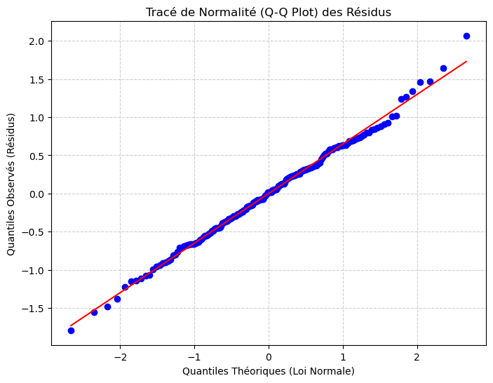

```python
# Utilisation du modèle statsmodels pour obtenir les résidus (la méthode la plus simple)
# Définir les variables finales à partir du DataFrame wine_minus_alc
from scipy import stats

variables_finales = wine_minus_alc.columns.tolist()

# Nous devons ré-ajuster le modèle OLS complet pour obtenir l'objet 'results'
X_sm = sm.add_constant(wine[variables_finales])
model_sm = sm.OLS(wine['Alcohol'], X_sm)
results_sm = model_sm.fit()

# Récupération des résidus (erreurs)
resid = results_sm.resid

# ----------------------------------------------------
# CODE POUR TRACER LA NORMALITÉ (Q-Q Plot)
# ----------------------------------------------------

plt.figure(figsize=(8, 6))

# stats.probplot est la fonction standard pour générer le Q-Q plot
# Elle compare les quantiles des résidus avec les quantiles théoriques d.une distribution normale
stats.probplot(resid, dist="norm", plot=plt)

plt.title("Tracé de Normalité (Q-Q Plot) des Résidus")
plt.xlabel("Quantiles Théoriques (Loi Normale)")
plt.ylabel("Quantiles Observés (Résidus)")
plt.grid(True, linestyle='--', alpha=0.6)
plt.show()

# Conclusion : Observer si les points suivent la ligne rouge.
```